# Bandcamp Memo: Over-payment Analysis

Author

Alex Scoggins, Bridget Hyland, Nick Carroll, Max Wark, Megan Manquen, Thao Nguyen

Published

December 10, 2022

# Overview:

Bandcamp is an online music platform in which artists of any size can list digital music or physical media for sale. What makes Bandcamp unique is the option for customers to pay above the listed price. While it is generally expected that customers prefer to pay the lowest price for an item, Bandcamp’s user base shows that a sizable portion of consumers display a willingness to pay a premium to support artists. This report will investigate the voluntary over-payments on the platform and show that factors such as item type, buyer location, and of course Bandcamp Friday, will impact how much customers typically overpay. This information is valuable because Bandcamp’s fee structure, which ranges from 10-15%, applies to the over-payment as well as the listing price. Customers that pay a premium benefit Bandcamp as well as the artist and actions can be taken to boost revenue that help both parties.

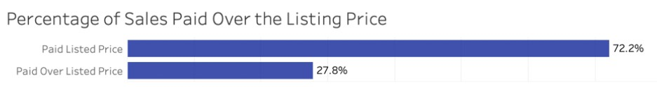

Our sample is composed of 1,000,000 individual Bandcamp transactions between September 10, 2020, and October 2, 2020. Our features include both the listed price and the price the buyer paid, allowing us to isolate the amount of over-payment on each transaction. At the highest level, we can see that in 28% of the observed transactions, the customer paid above the listed price.

# Over-payment Analysis:

## Item Type

We can also observe the product type for each transaction. Being a music distribution website, digital items make up the majority of the transactions, but physical items are still a notable portion. The items sold are divided among four categories: Digital Albums (which includes full digital discographies), Digital Tracks, Physical Albums, and Physical Merchandise. From here we can begin to look at differences in the amount customers overpaid across these item types. In order to compare across countries, all price figures in this report have been converted to US dollars.

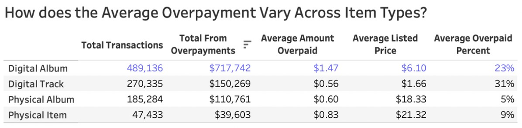

As we can see, digital albums are both the most frequent item purchased and the item in which customers pay the highest amount over listing price. Albums are a more cohesive vision for an artist and typically are priced at a lower price per track, which may lead to the preference for customers to purchase albums over tracks. In terms of over-payment, digital albums are a middle price point at an average of just over six dollars, which may mean that psychologically a couple extra dollars do not feel excessive in the way that an extra dollar on top of at one dollar track would double the price. While we can only speculate on the cause, digital albums clearly are the dominant source of premium revenue on Bandcamp.

## Regionally

Going a step further, the differences in over-payment apply not just to item categories, but to countries as well. Our sample includes buyers from across the world, but there is a heavy concentration at the top. The United States, United Kingdom, Germany, Australia, Canada, France, and Japan make up 80% of total sales on the platform, as demonstrated in the following chart.

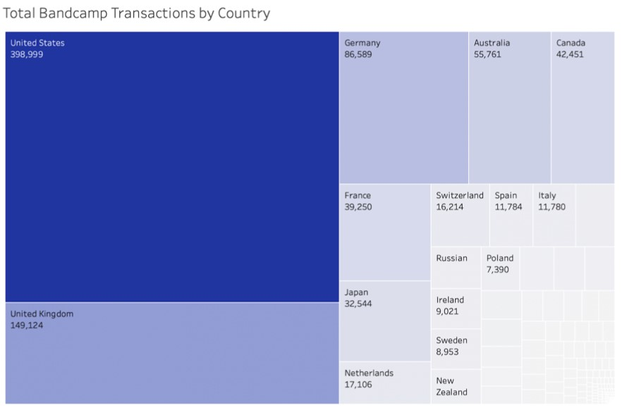

Patterns in payment premiums are also notably different across countries. While we can see in the graph below that over-payments are relatively high for digital albums across the top countries, the average premium in Japan averages just half of that in the United States. Among the top countries however, Japan is the only one that pays a higher premium on physical merchandise than on digital albums. And in the digital track category, the overall average premium of $0.56 shown earlier is largely propped up by the United States, Canada, and Australia, with premiums on digital tracks virtually non-existent in France and Germany.

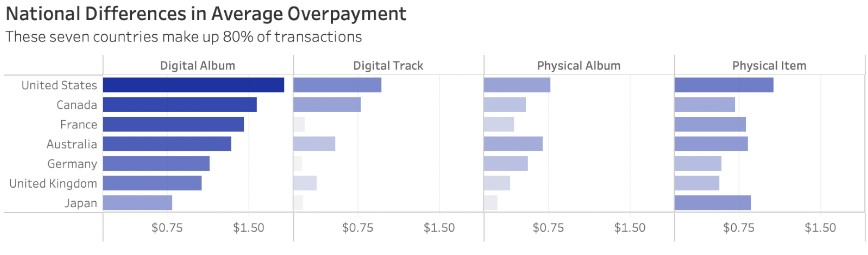

Ultimately, we are assuming that payment premiums reflect an additional value that a customer places on a specific item, which can be comparable as a form of tipping. It is possible that differences in tipping culture across countries capture some of the variance, but the digital album category shows that all the countries are willing to pay some level of premium. Bandcamp is a company with a strong social media presence, with Twitter and Instagram accounts that showcase new artists. Based on these consumer preferences, the company can potentially link to digital albums in posts in the United States and Canada, while also linking to physical merchandise in Japan. Posts can also prioritize marketing albums over tracks in Europe when possible, given the stark differences in those categories. Driving sales through these forms of marketing provides a symbiotic relationship that supports both Bandcamp and the artists.

## Free Items vs. Non-Free Items

Bandcamp also gives artists the choice to list their items as free or provide a listing price. This option gives artists the flexibility to choose how much they want to sell their items for and gives especially new artists the ability to list items as free to promote their work and garner fans. For artists listing their work as free on Bandcamp, they can benefit from customers who are willing to pay a premium for their work.

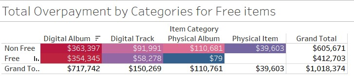

We can see that the total amount in US dollars paid in premiums over this period is largely concentrated in digital albums and discographies. Of the digital albums here, about 19% were listed as free while the remaining 81% had a listing price above zero. Only four total physical albums were listed as free, and no physical items were listed as free, so we will focus on the digital items. For digital albums, we can see that the sales brought in from the premium payments, over the listed prices, are relatively similar for free and non-free items. This suggests that while free digital albums make up only 19% of the digital albums available over this period, the total amount paid in premiums makes up for the lower volume of free items. It is important to note that these are only the sales brought in from the over-payment alone, so next we will address how this compares to how much customers are willing to pay in total for these free and non-free items.

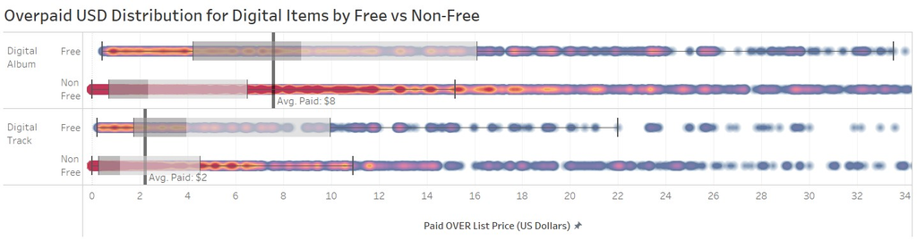

Here we can take a closer look at how our customers at Bandcamp are overpaying for digital items. Let’s again consider the digital albums category. We can see that the median amount overpaid for free digital albums, approximately $9 USD, is notably higher than median amount overpaid for non-free digital albums, approximately $2 USD. Comparing this to the average total amount paid for a digital album, approximately $8 USD, we find that customers seem to still be willing to pay in the $8-$9 USD range, regardless of if the album is listed as free or not. A similar finding appears when considering the digital tracks. By listing the item as free, as opposed to the average list price of $1.66 USD, artists are seeing customers willing to overpay on average by around $4 USD for their work. By prompting artists to utilize the option of listing items for free to attract new listeners and fans to their work, Bandcamp and the artists may still be seeing customers willing to pay about the same amount for the item.

[figure not shown]

Reviewing the average-amount-paid-over follows suit, with buyers generally paying higher amounts above the listed price for free items compared with non-free items. There are a handful of countries that appear to have higher averages than their counterparts in the free items category (Algeria, Central African Republic, and Ethiopia), however, the sample is too small to make any conclusions and can be explained away by outliers. The United States, the largest Bandcamp market, averages $4.01 over the “free” asking price compared with $.93 for items with a price associated.

[figure not shown]

## Bandcamp Friday

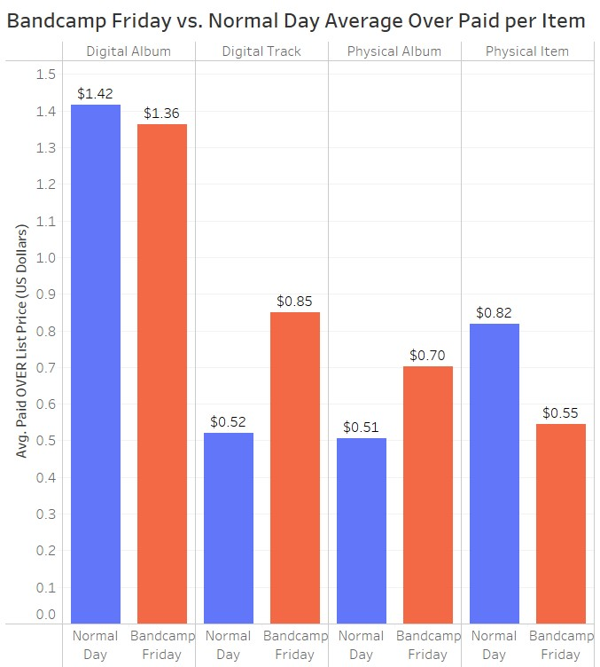

Our last point of analysis focuses on Bandcamp Friday where 100% of the proceeds go to artists. This was started during the beginning of the COVID-19 pandemic, and by September and October of 2020, the Bandcamp community was generally well aware of its existence. Luckily, our dataset includes one such day on October 2. With that said, the 1 millionth transaction (the breadth of our dataset) coincidentally occurred near the end of the day. So, while we do not have a full day’s data to reflect on, we can still review the transaction over-payment averages, shown below. What is noteworthy is that the differences between a normal day and a Bandcamp Fridays average over-payment is not astoundingly noteworthy. Yes, on digital tracks, we see that customers do indeed overpay on average $.33 more than on any other day, and $0.19 more for physical albums. However, for digital albums, customers are more willing to pay above expectations on a typical day other than a Bandcamp Friday, but only by about $0.06. In essence, people do make an effort to support artists when they know their dollar is going to go further, but not in a way that harms Bandcamp for the rest of the month. The fostering of goodwill within our community is indeed worth it.

# Final Recommendations:

Bandcamp regularly showcases artists through its social media accounts. These posts can link to item types more likely to earn a premium in that region, for example linking to digital albums in the United States while also linking to physical media in Japan.

Because of customers willingness to overpay and to do so even more so for items listed as free, Bandcamp remains in the same ballpark of fees brought into the company regardless of if the items are listed as free or not. This is suggested by the customers’ paying, on average over this period, in the same ballpark by item for digital tracks and albums. Bandcamp can utilize this information to market to new artists, who may be more interested in listing their items as free, to as a tool for them to use and a benefit of them using Bandcamp for their work. This is beneficial for both the artists and Bandcamp alike.

#### *Data Source: [**Kaggle**](https://www.kaggle.com/datasets/mathurinache/1000000-bandcamp-sales)